# Week 11: Panel Data Causal Inference

PS 813 - Causal Inference

Anton Strezhnev

strezhnev@wisc.edu

University of Wisconsin-Madison

April 5, 2027

$$\require{cancel}$$

## Last two weeks

- Differences-in-differences designs for dealing with unobserved confounding.
- Identification under **Parallel trends**

  $$\mathbb{E}[Y_{it}(0) - Y_{it^{\prime}}(0) \mid D_i = 1] - \mathbb{E}[Y_{it}(0) - Y_{it^{\prime}}(0) \mid D_i = 0]$$
- Estimation via **first-differences** regression (Callaway and Sant’Anna, 2021)
  - Can adjust for **time-varying** and **time-invariant** threats to parallel trends.
- Pre-treatment **placebo test** diagnostics
- Be careful with software defaults!

## This week

- In DiD, our identifying assumptions **rule out** outcome-treatment feedback
  - Treatment is **exogenous** conditional on observed and unobserved (but structurally constrained) factors
  - But past outcomes do not directly affect present treatment.
- Not uncommon to have **dynamic** treatment settings where this assumption is violated.
  - Doctors change treatment regimen in response to patient outcomes.
  - Political campaigns adjust their strategy in response to observed poll numbers.
  - Economic growth affects democratization (which affects economic growth)
- In all of these settings, we have $Y_{t-1}$ affecting treatment $D_{t}$
  - And typically also lagged **treatment** $D_{t-1}$ affecting current treatment $D_{t}$

## Review: DiD and Strict Exogeneity

- For this section, we’re going to work with binary treatment $D_{it}$ observed at each time period $t$
  - For simplicity, we’ll consider **two** time periods generically as $t$ and $t-1$
  - Let $D_i = \{D_{i1}, D_{i2}, D_{i3}, \dotsc, D_{iT}\}$ denote the entire treatment **history** for a unit
- In DiD, our **parallel trends** assumption is a special case of a particular kind of exogeneity/ignorability assumption
  - We assume that treatment history is **as-good-as-randomly** assigned given observed covariates **and** some latent factor
  - Let $\mathbf{X}_i = \{X_{i1}, X_{i2}, X_{i3}, \dotsc, X_{iT}\}$ denote the unit’s observed covariate history
  - Let $\mathbf{U}_i = \{U_{i1}, U_{i2}, U_{i3}, \dotsc, U_{iT}\}$ denote the unit’s latent factor history
- **Strict exogeneity**

  $$\{Y_{it}(0), Y_{it}(1) \} \perp\!\!\!\perp D_{i} \mid \mathbf{X}_{i}, \mathbf{U}_i$$

## Strict exogeneity

[figure not shown]

Adapted from Xu (2023) ‘Causal Inference with Time-Series Cross-Sectional Data: A Reflection’

## DiD and parallel trends

- If we want to identify the effect of $D_{t}$ on $Y_{t}$ (the “instantaneous” effect), via a standard selection-on-observables design, we would need to adjust for both $X$ and $U$
- But here, we’ve supposed that $U$ is **unobserved** - can’t control for it directly.
  - We need **more assumptions**!
- DiD works by making an additional **functional form** assumption about the latent factor.
  - We assume that we can decompose the latent factor into two additive components: $U_{it} = \alpha_i + \delta_t$
- This gives us the classic **two-way fixed effect** formulation:

  $$Y_{it}(0) = \alpha_i + \delta_t + f(\mathbf{X}_i) + \varepsilon_{it}$$

## DiD and parallel trends

- It’s straightforward to see under this functional form assumption and the **strict exogeneity** assumption, we get **parallel trends**

  $$\mathbb{E}[Y_{it}(0) - Y_{it-1}(0) \mid D_{it} = 0, \mathbf{X}] = \mathbb{E}[Y_{it}(0) - Y_{it-1}(0) \mid D_{it} = 1, \mathbf{X}] = \delta_{t} - \delta_{t-1}$$
- Under strict exogeneity $\text{Cov}(\varepsilon_{it}, D_{it}) = 0$

## Sequential ignorability

- But in many panel data settings, ruling out the arrow from $Y_{t-1}$ to $D_{t}$ is implausible!
  - We’ll need to make a **different** assumption
  - Before that though, we need to define the potential outcomes in a new way!
- We now have to consider potential outcomes in terms of the entire **treatment history** assigned up to time $t$

  $$Y_{it}(d_1, d_2, \dotsc, d_t) = Y_{it}(d_{1:t})$$
- We can partition this joint potential outcome into the **contemporaneous** treatment $d_t$ and past values $d_1, d_2, \dotsc, d_{t-1}$

  $$Y_{it}(d_{1:t}) = Y_{it}(d_{t}; d_{1:t-1})$$
- We’ll define the **Contemporaneous Effect** of treatment at time $t$ as:

  $$Y_{it}(1; d_{1:t-1}) - Y_{it}(0; d_{1:t-1}) = Y_{it}(1) - Y_{it}(0)$$
- Later on when we talk about **mediation**, we’ll introduce other kinds of estimands for **cumulative** effects over time.

## Sequential ignorability

- Identification of causal effects under outcome-treatment feedback can be done under a **sequential ignorability** assumption (Robins, 1986; Blackwell and Glynn, 2018).
- At each time period, treatment is as-if random conditional on observed covariate and outcome history

  $$\{Y_{it}(1), Y_{it}(0)\} \perp\!\!\!\perp D_{it} \mid X_{it}, Y_{it-1}, D_{it-1}$$
- We can relax this by conditioning on a **longer** history of outcomes, treatments and covariates.
- Here we’re focusing on the version of sequential ignorability needed for the contemporaneous treatment effect, but can make it more **general**

  $$\{Y_{is}(d_{1:s}) : s = t, \dotsc, T\} \perp\!\!\!\perp D_{it} \mid X_{it}, Y_{it-1}, D_{it-1}$$
- We’ll cover this more when we talk about **mediation**

## Sequential ignorability

[figure not shown]

Adapted from Blackwell and Glynn (2018) ‘How to Make Causal Inferences with Time-Series Cross-Sectional Data under Selection on Observables’

## Estimation of treatment effects

- Under sequential ignorability, we can motivate estimation of the **contemporaneous** effect of treatment using an Autoregressive Distributed Lag (ADL) model framework.
  - Adjust for some number of **lagged** outcomes (autoregressive)
  - Adjust for some number of **lagged** treatments (distributed lag)
- For example, a one-lag linear model

  $$Y_{it} = X_{it}^\prime\beta + \alpha Y_{it-1} + \tau_0 D_{it} + \tau_1 D_{it-1} + \varepsilon_{it}$$
- If we believe the parametric assumptions behind this model (e.g. constant effects), $\tau_0$ identifies the **average** contemporaneous effect of treatment at time $t$.
- But does $\tau_1$ identify the effect **one period out**?
  - No! We have **post-treatment** bias **(Blackwell and Glynn, 2018)**.
  - This is the **Table 2 fallacy** all over again.

## Sequential ignorability

[figure not shown]

Adapted from Blackwell and Glynn (2018) ‘How to Make Causal Inferences with Time-Series Cross-Sectional Data under Selection on Observables’

## LDV vs. DiD

- We’ll talk about how to estimate these long-term and cumulative effects under **sequential ignorability** when we get to mediation in a few weeks.
  - The relevant estimands and estimators come from this literature.
  - Future treatment and covariates are **mediators** of past treatment!
- But let’s consider the **simple setting** with two time periods and two treatment groups
  - Everyone is under **control** at time $t-1$, some units are treated at time $t$
- **Two** possible ways to estimate the treatment effect.
  1. **Difference-in-differences** - Regress $Y_{it} - Y_{it-1}$ on $D_{it}$
  2. **Lagged-DV adjustment** - Regress $Y_{it}$ on $D_{it}$ and $Y_{it-1}$

## Controlling for LDV under strict exogeneity

- What happens if we control for the lagged dependent variable under strict exogeneity?
- What we **actually** want to do is adjust for the **expected** lagged outcome.
  - But the actual observed outcome contains **random error**
  - $Y_{it-1}$ can be high because of the **latent factor** or the **error**
- We are controlling for an **imperfect** proxy of the true confounder
- This measurement error induces a bias due to **reversion to the mean**
  - If treated units tend to be higher in their outcomes than control (on average), then control units with similar **observed** outcomes are **outliers**
  - We’d expect the subsequent outcome to be closer to the mean if there’s independent noise at $t$ versus $t-1$

## Simulation: Controlling for LDV

- To see the bias from controlling for lagged $Y$, consider the following DGP:
  - $N = 2000$ units, two periods ($t{-}1$ and $t$), true treatment effect $\tau = 0$
  - Time-invariant confounder: $\alpha_i \sim N(0, 1)$
  - Treatment correlated with confounder: $D_i \sim \text{Bernoulli}(\text{logit}^{-1}(\alpha_i))$
  - Outcome at $t{-}1$: $Y_{it-1} = \alpha_i + \varepsilon_{it-1}$, where $\varepsilon_{it-1} \sim N(0, \sigma_\varepsilon^2)$
  - Outcome at $t$: $Y_{it} = \alpha_i + \tau D_i + \varepsilon_{it}$, where $\varepsilon_{it} \sim N(0, \sigma_\varepsilon^2)$
- **Parallel trends** holds by construction: $\alpha_i$ is time-invariant
- Vary $\sigma_\varepsilon \in \{0.5, 1, 2, 4, 8\}$ to control how **noisy** the proxy $Y_{it-1}$ is for $\alpha_i$
- Compare three estimators: simple difference-in-means post-treatment, DiD, and LDV

## Simulation: LDV bias from measurement error

```r
set.seed(53703)
N <- 2000
n_sims <- 500
noise_levels <- c(0.5, 1, 2, 4, 8)

sim_results <- map_dfr(noise_levels, function(sigma_e) {
  map_dfr(1:n_sims, function(s) {
    # Time-invariant confounder
    alpha_i <- rnorm(N, 0, 1)
    # Treatment correlated with confounder
    D_i <- rbinom(N, 1, plogis(alpha_i))
    # True treatment effect is ZERO
    beta <- 0
    # Pre and post outcomes: parallel trends holds
    Y_pre <- alpha_i + rnorm(N, 0, sigma_e)
    Y_post <- alpha_i + beta * D_i + rnorm(N, 0, sigma_e)

    # Difference-in-means (biased by alpha_i)
    dim_est <- coef(lm(Y_post ~ D_i))["D_i"]
    # DiD (unbiased)
    did_est <- coef(lm(I(Y_post - Y_pre) ~ D_i))["D_i"]
    # LDV (biased -- errors in variables)
    ldv_est <- coef(lm(Y_post ~ D_i + Y_pre))["D_i"]

    tibble(sigma_e = sigma_e, sim = s,
           `Diff-in-means` = dim_est, DiD = did_est, LDV = ldv_est)
  })
})

sim_summary <- sim_results %>%
  pivot_longer(cols = c(`Diff-in-means`, DiD, LDV),
               names_to = "Estimator", values_to = "estimate") %>%
  group_by(sigma_e, Estimator) %>%
  summarize(mean_est = mean(estimate),
            ci_low = quantile(estimate, 0.025),
            ci_high = quantile(estimate, 0.975), .groups = "drop")

sim_summary$Estimator <- factor(sim_summary$Estimator,
                                levels = c("Diff-in-means", "LDV", "DiD"))

ggplot(sim_summary, aes(x = factor(sigma_e), y = mean_est,
                        color = Estimator, group = Estimator)) +
  geom_point(size = 3, position = position_dodge(width = 0.4)) +
  geom_errorbar(aes(ymin = ci_low, ymax = ci_high),
                width = 0.3, position = position_dodge(width = 0.4)) +
  geom_hline(yintercept = 0, linetype = "dashed") +
  labs(x = expression(paste("Noise in pre-treatment outcome (", sigma[epsilon], ")")),
       y = "Estimate",
       title = "LDV bias under the DiD model (true effect = 0)",
       subtitle = "More noise in Y(pre) = worse proxy for confounder = more residual bias") +
  scale_color_manual(values = c("Diff-in-means" = "gray60",
                                "LDV" = "dodgerblue",
                                "DiD" = "indianred")) +
  theme_bw() + theme(legend.position = "bottom")
```

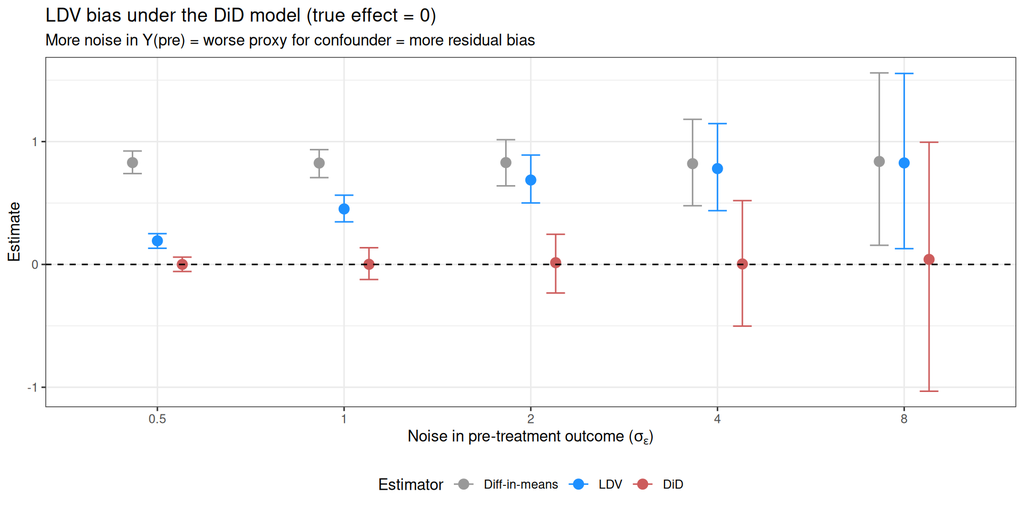

## Simulation: What if outcomes are autocorrelated?

- In the previous simulation, $\varepsilon_{it-1}$ and $\varepsilon_{it}$ are **independent** — the only thing linking outcomes over time is $\alpha_i$
- In practice, outcomes are often **autocorrelated**: a unit that is high at $t{-}1$ (beyond $\alpha_i$) tends to stay high at $t$
- Modified DGP: let $\varepsilon_{it} = \rho \cdot \varepsilon_{it-1} + \nu_i$ where $\nu_i \sim N(0, \sigma_\varepsilon^2)$
  - When $\rho > 0$, $Y_{it-1}$ is a **better proxy** for $Y_{it}$’s non-treatment component
  - LDV should perform better because controlling for $Y_{it-1}$ captures more of the variation
- We fix $\sigma_\varepsilon = 2$ and vary $\rho \in \{0, 0.25, 0.5, 0.75, 0.95\}$

## Simulation: Autocorrelation reduces LDV bias

```r
set.seed(53703)
N <- 2000
n_sims <- 500
sigma_e <- 2
rho_levels <- c(0, 0.25, 0.5, 0.75, 0.95)

sim_results_rho <- map_dfr(rho_levels, function(rho) {
  map_dfr(1:n_sims, function(s) {
    alpha_i <- rnorm(N, 0, 1)
    D_i <- rbinom(N, 1, plogis(alpha_i))
    beta <- 0

    eps_pre <- rnorm(N, 0, sigma_e)
    eps_post <- rho * eps_pre + rnorm(N, 0, sigma_e)

    Y_pre <- alpha_i + eps_pre
    Y_post <- alpha_i + beta * D_i + eps_post

    dim_est <- coef(lm(Y_post ~ D_i))["D_i"]
    did_est <- coef(lm(I(Y_post - Y_pre) ~ D_i))["D_i"]
    ldv_est <- coef(lm(Y_post ~ D_i + Y_pre))["D_i"]

    tibble(rho = rho, sim = s,
           `Diff-in-means` = dim_est, DiD = did_est, LDV = ldv_est)
  })
})

sim_summary_rho <- sim_results_rho %>%
  pivot_longer(cols = c(`Diff-in-means`, DiD, LDV),
               names_to = "Estimator", values_to = "estimate") %>%
  group_by(rho, Estimator) %>%
  summarize(mean_est = mean(estimate),
            ci_low = quantile(estimate, 0.025),
            ci_high = quantile(estimate, 0.975), .groups = "drop")

sim_summary_rho$Estimator <- factor(sim_summary_rho$Estimator,
                                    levels = c("Diff-in-means", "LDV", "DiD"))

ggplot(sim_summary_rho, aes(x = factor(rho), y = mean_est,
                            color = Estimator, group = Estimator)) +
  geom_point(size = 3, position = position_dodge(width = 0.4)) +
  geom_errorbar(aes(ymin = ci_low, ymax = ci_high),
                width = 0.3, position = position_dodge(width = 0.4)) +
  geom_hline(yintercept = 0, linetype = "dashed") +
  labs(x = expression(paste("Autocorrelation (", rho, ")")),
       y = "Estimate",
       title = expression(paste("LDV bias with autocorrelated errors (", sigma[epsilon], " = 2, true effect = 0)")),
       subtitle = "More autocorrelation = lagged Y is better proxy = less LDV bias") +
  scale_color_manual(values = c("Diff-in-means" = "gray60",
                                "LDV" = "dodgerblue",
                                "DiD" = "indianred")) +
  theme_bw() + theme(legend.position = "bottom")
```

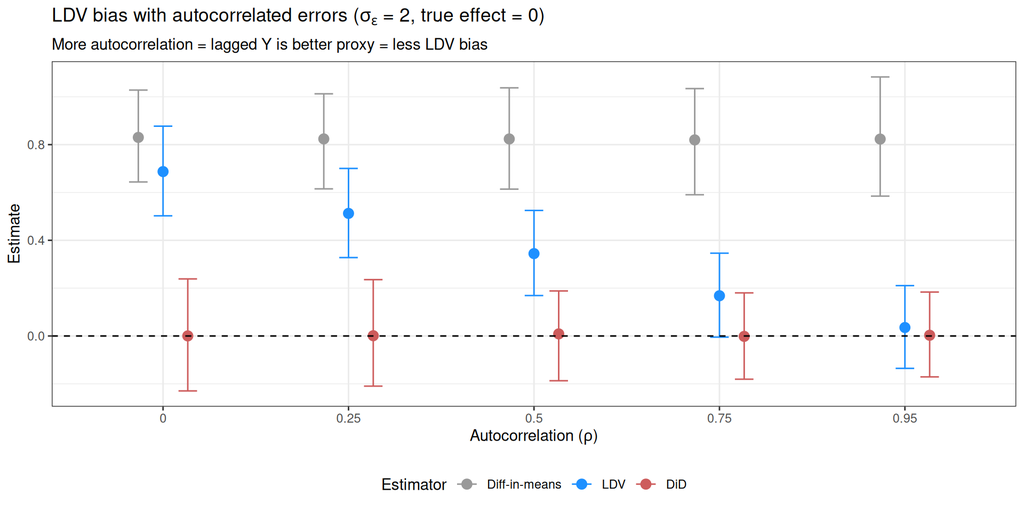

## Illustration: The Effects of the Shale Shock

- Let’s return to our example of the effect of the “shale shock” on coal county voting for the Republican party (Gazmararian, 2025).
  - Last week we showed concerning evidence of a **parallel trends** violation - coal-heavy regions were already trending Republican prior to 2008.
  - Extrapolating the trend (triple-differences in time) eliminates the observed effect.
- What if, instead of DiD, we **controlled** for lagged Republican party vote share in 2004 and 2000.

## Lagged DV approach: Setup

```r
dff <- readRDS("assets/data/matched_df.rds")
dff <- dff %>% filter(!is.na(oilgas_prop))

# Create wide-format lagged outcomes
lag_vars <- dff %>%
  select(county_state, year, RepVotesMajorPercent) %>%
  pivot_wider(names_from = year, values_from = RepVotesMajorPercent,
              names_prefix = "Y_")

dff <- dff %>% left_join(lag_vars, by = "county_state")
```

## Lagged DV: Estimates by year

```r
# LDV regressions for each post-treatment year
ldv_years <- c(2008, 2012, 2016, 2020)
ldv_results <- map_dfr(ldv_years, function(yr) {
  df_yr <- dff %>% filter(year == yr)
  fit <- estimatr::lm_robust(
    RepVotesMajorPercent ~ treat + Y_2004 + Y_2000 + oilgas_prop,
    data = df_yr, clusters = county_state, se_type = "stata")
  tidy_fit <- broom::tidy(fit) %>% filter(term == "treat")
  tidy_fit$year <- yr
  tidy_fit
})

ggplot(ldv_results, aes(x = year, y = estimate)) +
  geom_point(size = 3) +
  geom_errorbar(aes(ymin = conf.low, ymax = conf.high), width = 0.5) +
  geom_hline(yintercept = 0, linetype = "dashed") +
  geom_vline(xintercept = 2006, linetype = "dashed", color = "red") +
  labs(x = "Year", y = "Estimate (pp)",
       title = "LDV: Effect of coal county on Republican vote share",
       subtitle = "Controlling for Y[2004], Y[2000], and oil/gas employment") +
  scale_x_continuous(breaks = ldv_years) +
  theme_bw()
```

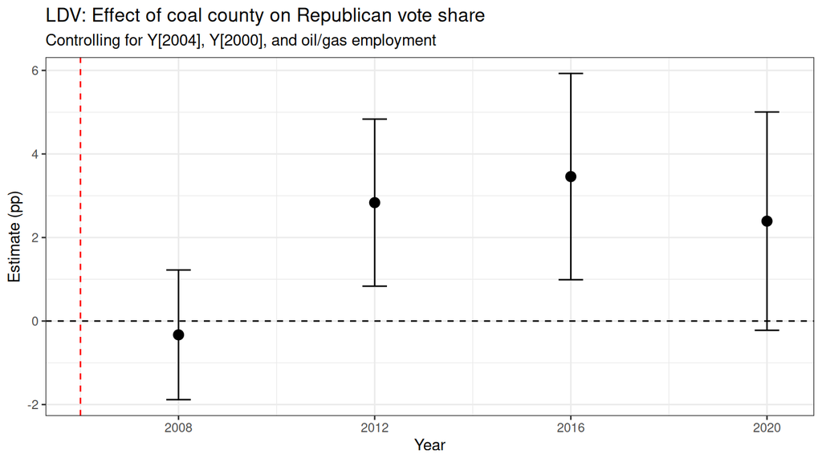

## DiD: Estimates by year

```r
# DiD regressions for each post-treatment year
did_results <- map_dfr(ldv_years, function(yr) {
  df_yr <- dff %>%
    filter(year == yr) %>%
    mutate(dY = RepVotesMajorPercent - Y_2004)
  fit <- estimatr::lm_robust(
    dY ~ treat + oilgas_prop,
    data = df_yr, clusters = county_state, se_type = "stata")
  tidy_fit <- broom::tidy(fit) %>% filter(term == "treat")
  tidy_fit$year <- yr
  tidy_fit
})

ggplot(did_results, aes(x = year, y = estimate)) +
  geom_point(size = 3) +
  geom_errorbar(aes(ymin = conf.low, ymax = conf.high), width = 0.5) +
  geom_hline(yintercept = 0, linetype = "dashed") +
  geom_vline(xintercept = 2006, linetype = "dashed", color = "red") +
  labs(x = "Year", y = "Estimate (pp)",
       title = "DiD: Effect of coal county on change in Republican vote share",
       subtitle = "Outcome: Y[t] - Y[2004], controlling for oil/gas employment") +
  scale_x_continuous(breaks = ldv_years) +
  theme_bw()
```

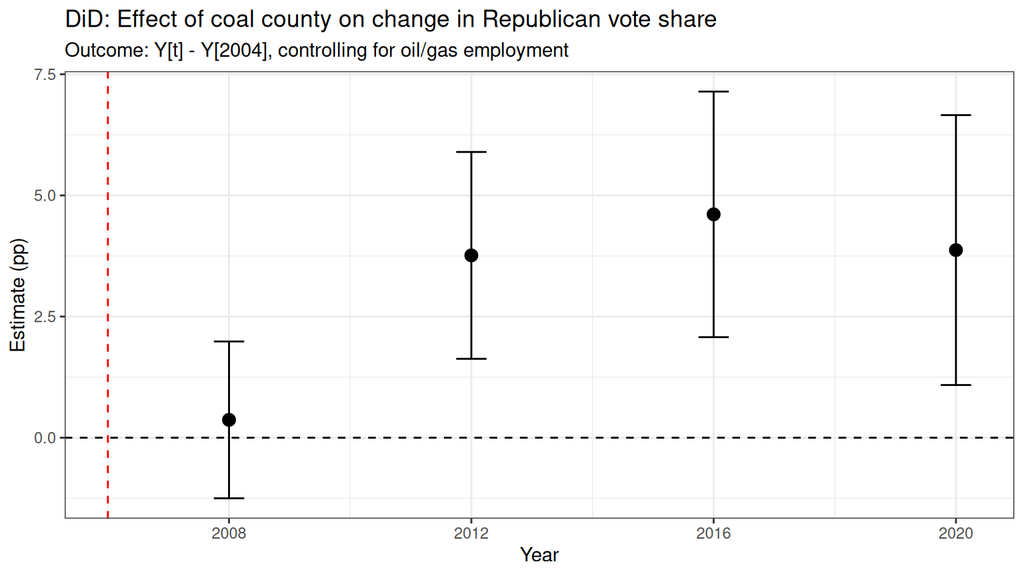

## Comparing LDV and DiD

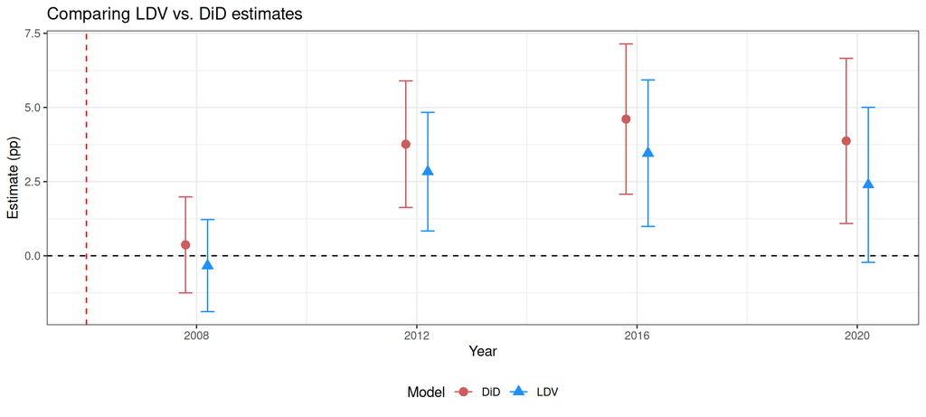

## Placebo test: Pre-treatment hold-out

- Let’s construct a **placebo test** for the lagged DV approach.
  - Because we have many pre-treatment periods, we can apply the LDV approach to **pre-treatment** outcomes
- **Placebo 1**: Outcome year 2004, controlling for $Y_{2000}$ and $Y_{1996}$
- **Placebo 2**: Outcome year 2000, controlling for $Y_{1996}$ and $Y_{1992}$
- **Placebo 3**: Outcome year 1996, controlling for $Y_{1992}$ and $Y_{1988}$

## Placebo: LDV estimates

```r
# Placebo LDV regressions (2 lagged controls, matching main spec)
placebo_ldv_results <- bind_rows(
  # 2004 outcome, controlling for 2000, 1996
  {
    df_yr <- dff %>% filter(year == 2004)
    fit <- estimatr::lm_robust(
      RepVotesMajorPercent ~ treat + Y_2000 + Y_1996 + oilgas_prop,
      data = df_yr, clusters = county_state, se_type = "stata")
    broom::tidy(fit) %>% filter(term == "treat") %>% mutate(year = 2004)
  },
  # 2000 outcome, controlling for 1996, 1992
  {
    df_yr <- dff %>% filter(year == 2000)
    fit <- estimatr::lm_robust(
      RepVotesMajorPercent ~ treat + Y_1996 + Y_1992 + oilgas_prop,
      data = df_yr, clusters = county_state, se_type = "stata")
    broom::tidy(fit) %>% filter(term == "treat") %>% mutate(year = 2000)
  },
  # 1996 outcome, controlling for 1992, 1988
  {
    df_yr <- dff %>% filter(year == 1996)
    fit <- estimatr::lm_robust(
      RepVotesMajorPercent ~ treat + Y_1992 + Y_1988 + oilgas_prop,
      data = df_yr, clusters = county_state, se_type = "stata")
    broom::tidy(fit) %>% filter(term == "treat") %>% mutate(year = 1996)
  }
)

ggplot(placebo_ldv_results, aes(x = year, y = estimate)) +
  geom_point(size = 3) +
  geom_errorbar(aes(ymin = conf.low, ymax = conf.high), width = 0.5) +
  geom_hline(yintercept = 0, linetype = "dashed") +
  labs(x = "Year", y = "Estimate (pp)",
       title = "Placebo test: LDV estimates in pre-treatment periods",
       subtitle = "Each placebo controls for two prior election outcomes + oil/gas share") +
  scale_x_continuous(breaks = c(1996, 2000, 2004)) +
  theme_bw()
```

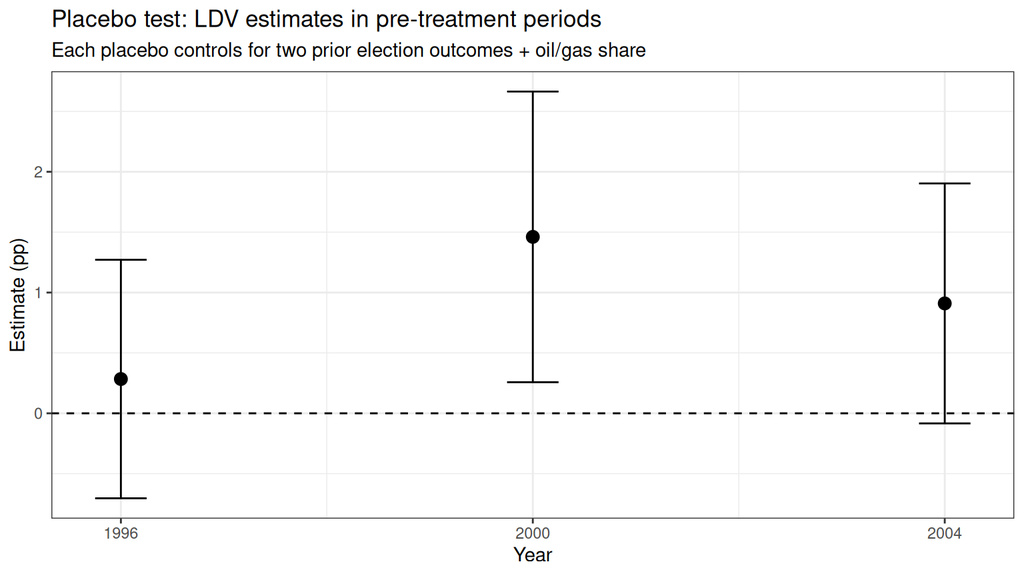

## Bracketing: Angrist and Pischke (2009)

- **Angrist and Pischke (2009, Ch. 5.4)** show that LDV and DiD estimates **bracket** the true causal effect if **one** of the two identifying assumptions holds.
  - Focus on the simple linear model case - **Ding and Li (2019)** extend to the non-parametric setting.
- Two-period DiD. All units under control at time $0$
  - Assume $\tau > 0$ (positive effect)
- For exposition, assume time-effects are already removed via differencing and no covariates.

## Bracketing: Case 1 – DiD is correct, LDV is misspecified

- Suppose the **FE model** is the truth:

  $$Y_{it} = \alpha_i + \tau D_{it} + \varepsilon_{it}$$

  where $\varepsilon_{it}$ is serially uncorrelated and independent of $\alpha_i$ and $D_{it}$. Since $D_{it-1} = 0$: $Y_{it-1} = \alpha_i + \varepsilon_{it-1}$
- You mistakenly estimate the **LDV regression** (controlling for $Y_{it-1}$ instead of $\alpha_i$):

  $$Y_{it} = a + b \cdot Y_{it-1} + \tau^{\text{LDV}} D_{it} + u_{it}$$

## Bracketing: Case 1 – FWL decomposition

- By FWL, the LDV estimand is $\hat{\tau}^{\text{LDV}} \xrightarrow{p} \frac{\text{Cov}(Y_{it}, \tilde{D}_{it})}{\text{Var}(\tilde{D}_{it})}$
  - $\tilde{D}_{it} = D_{it} - \hat{\gamma} Y_{it-1}$ is the residual from the auxiliary regression of $D_{it}$ on $Y_{it-1}$
- To evaluate this, substitute $\alpha_i = Y_{it-1} - \varepsilon_{it-1}$ into the true model:

  $$Y_{it} = \alpha_i + \tau D_{it} + \varepsilon_{it} = (Y_{it-1} - \varepsilon_{it-1}) + \tau D_{it} + \varepsilon_{it}$$

  $$\Rightarrow Y_{it} = Y_{it-1} + \tau D_{it} + (\varepsilon_{it} - \varepsilon_{it-1})$$

## Bracketing: Case 1 – Deriving the bias

- Substitute in and use properties of covariances

  $$\frac{\text{Cov}(Y_{it}, \tilde{D}_{it})}{\text{Var}(\tilde{D}_{it})} = \frac{\text{Cov}(Y_{it-1} + \tau D_{it} + \varepsilon_{it} - \varepsilon_{it-1},\; \tilde{D}_{it})}{\text{Var}(\tilde{D}_{it})}$$
- $\text{Cov}(Y_{it-1}, \tilde{D}_{it}) = 0$ by construction (FWL residualizes out $Y_{it-1}$)
- $\text{Cov}(D_{it}, \tilde{D}_{it}) = \text{Var}(\tilde{D}_{it})$
- $\text{Cov}(\varepsilon_{it}, \tilde{D}_{it}) = 0$ since $\varepsilon_{it} \perp\!\!\!\perp (D_{it}, Y_{it-1})$
- But $\text{Cov}(\varepsilon_{it-1}, \tilde{D}_{it}) = \text{Cov}(\varepsilon_{it-1}, D_{it}) - \hat{\gamma}\text{Cov}(\varepsilon_{it-1}, Y_{it-1})$
  - And since $Y_{it-1} = \alpha_i + \varepsilon_{it-1}$…
  - $\text{Cov}(\varepsilon_{it-1}, \tilde{D}_{it}) = -\hat{\gamma}\sigma^2_{\varepsilon}$
- So: $\hat{\tau}^{\text{LDV}} \xrightarrow{p} \tau + \frac{\hat{\gamma} \sigma^2_\varepsilon}{\text{Var}(\tilde{D}_{it})}$, with bias having the **same sign** as $\hat{\gamma}$ (the sign of selection)

## Bracketing: Case 1 – Why is LDV biased?

- $Y_{it-1} = \alpha_i + \varepsilon_{it-1}$ is a **noisy proxy** for the confounder $\alpha_i$
  - Controlling for a noisy proxy does not fully remove confounding
- With **positive selection** (high outcome $\leadsto$ more likely to be treated) ($\hat{\gamma} > 0$)
  - LDV **overestimates** $\tau$
- With **negative selection** ($\hat{\gamma} < 0$)
  - LDV **underestimates** $\tau$

## Bracketing: Case 2 – LDV is correct, DiD is misspecified

- Now suppose the **LDV model** is the truth:

  $$Y_{it} = \alpha + \theta Y_{it-1} + \tau D_{it} + \varepsilon_{it}$$
- Where $\varepsilon_{it}$ is serially uncorrelated, $0 < \theta < 1$ (stationary)
- You mistakenly estimate the **first-differenced regression** (no control for $Y_{it-1}$):

  $$\Delta Y_{it} = a + \tau^{\text{DiD}} D_{it} + u_{it}$$

  where $\Delta Y_{it} = Y_{it} - Y_{it-1}$ and $D_{it-1} = 0$ for everyone

## Bracketing: Case 2 – FWL decomposition

- The DiD estimand is $\hat{\tau}^{\text{DiD}} \xrightarrow{p} \frac{\text{Cov}(\Delta Y_{it}, D_{it})}{\text{Var}(D_{it})}$
- Subtract $Y_{it-1}$ from both sides of the true model:

  $$Y_{it} - Y_{it-1} = \alpha + (\theta - 1)Y_{it-1} + \tau D_{it} + \varepsilon_{it}$$
- So $\Delta Y_{it} = \alpha + (\theta - 1)Y_{it-1} + \tau D_{it} + \varepsilon_{it}$. Substituting:

  $$\frac{\text{Cov}(\Delta Y_{it}, D_{it})}{\text{Var}(D_{it})} = \frac{\text{Cov}(\alpha + (\theta - 1)Y_{it-1} + \tau D_{it} + \varepsilon_{it}, D_{it})}{\text{Var}(D_{it})}$$

  $$\frac{\text{Cov}(\Delta Y_{it}, D_{it})}{\text{Var}(D_{it})} = \tau + (\theta - 1)\frac{\text{Cov}(Y_{it-1}, D_{it})}{\text{Var}(D_{it})} + \frac{\text{Cov}(\varepsilon_{it}, D_{it})}{\text{Var}(D_{it})}$$
- $\text{Cov}(\varepsilon_{it}, D_{it}) = 0$ by assumption (LDV model has no unobserved confounding)

## Bracketing: Case 2 – Deriving the bias

- Therefore:

  $$\hat{\tau}^{\text{DiD}} \xrightarrow{p} \tau + (\theta - 1)\frac{\text{Cov}(Y_{it-1}, D_{it})}{\text{Var}(D_{it})}$$
- The bias is $(\theta - 1)\frac{\text{Cov}(Y_{it-1}, D_{it})}{\text{Var}(D_{it})}$
- The bias has the **opposite sign** from the selection:
  - With positive selection ($\text{Cov}(Y_{it-1}, D_{it}) > 0$) and $\theta < 1$: bias is **negative** → DiD underestimates
  - With negative selection: bias is **positive** → DiD overestimates
- Under this model, **LDV is unbiased**: it correctly controls for $Y_{it-1}$

## Bracketing

- Combining both cases with **positive selection** ($\text{Cov}(\alpha_i, D_i) > 0$):
  - If strict exogeneity is correct: LDV overestimates, DiD is exact
  - If sequential ignorability is correct: DiD underestimates, LDV is exact
- The true effect is **bracketed** between the two estimates if **one** of these two assumptions is true.
- This is a useful result, but important to be aware of its limitations
  - It guarantees nothing if **neither assumption** is true!
- In many cases, we’re skeptical of **parallel trends** but we don’t think **sequential ignorability** is right either
  - Rather, we think the unobserved latent factor structure might be more complicated than $U_{it} = \alpha_i + \delta_t$
  - What do we do then?

## Synthetic Controls

## The Synthetic Control Method

- **Comparative case studies** in the social sciences try to assess the impact of some event by comparing the case of interest to some unaffected units
  - We ideally want to pick units that are **similar** enough that they share the same **latent characteristics** shaping the evolution of the outcome.
- The **Synthetic Control Method** (SCM) builds on this intuition (Abadie and Gardeazabal, 2003; Abadie, Diamond, and Hainmueller, 2010).
  - What if instead of using a single comparison, we use a **weighted average** of those units.
  - Find weights on the control units that reproduce the pre-treatment outcome trajectory of the treated unit
  - Compare the **observed** outcome trajectory to the **synthetic control** average.
- Justified under **two** different outcome models
  - Under **sequential ignorability**, we get an unbiased estimator (because past outcomes are direct confounders)
  - Under a **latent factor model**, the bias goes away as the **number of time periods** gets large.

## SCM: Setup and Notation

- Observe outcomes $Y_{it}$ for units $i = 1, \dotsc, J+1$ over periods $t = 1, \dotsc, T$
  - Let $T_0$ denote the number of **pre-treatment** periods, $T_1$ the number of **post-treatment**
  - Unit $i = 1$ is the treated unit, exposed to treatment starting at $T_0 + 1$
  - Units $i = 2, \dotsc, J+1$ are **donor** units (never treated)
- We want to estimate:

  $$\tau_{1t} = Y_{1t}(1) - Y_{1t}(0) \quad \text{for } t > T_0$$
- We define a set of **weights** on the donor units $\mathbf{W} = (w_2, \dotsc, w_{J+1})$ with $w_j \geq 0$ and $\sum_j w_j = 1$
- Estimate the effect by comparing the **observed** outcome to the **imputed counterfactual**

  $$\hat{\tau_{1t}} = Y_{1t} - \sum_{j=2}^{J+1} w_j Y_{jt}$$

## SCM: The data-generating process

- The SCM is typically motivated by an underlying **latent factor model** for the outcome

  $$Y_{it}(0) = \delta_t + \mathbf{\theta}_t \mathbf{Z}_i + \boldsymbol{\lambda}_t' \boldsymbol{\mu}_i + \varepsilon_{it}$$
- $\mathbf{Z}_i$ are the **observed covariates** (with time-varying coefficients $\mathbf{\theta}_t$).
- $\boldsymbol{\lambda}_t$ are $F$-dimensional time-varying factors and $\boldsymbol{\mu}_i$ are unit-specific loadings
- This is a more **general** model of latent unobserved confounding than DiD
  - In DiD, there is a **single** common time trend across all factors $\boldsymbol{\lambda}_t = \lambda$
  - The latent factor model allows for some number of **varying** time-trends across units (elements of $\boldsymbol{\lambda}_t$) that apply to different units (weights dictated by $\boldsymbol{\mu}_i$).

## SCM: Choosing the weights

- The goal of the synthetic control method is to find weights such that the weighted average of **donor** units reproduces the covariates and the pre-treatment trajectory of the treated unit

  $$\sum_{j=2}^{J+1} w^*_j Y_{jt} = Y_{1t} \quad \text{for } t \in \{1, 2, \dotsc, T_0\}$$

  $$\sum_{j=2}^{J+1} w^*_j \mathbf{Z}_j = \mathbf{Z}_{1}$$
- For notational simplicity, we’ll denote the $K \times J+1$ matrix of combined covariates and pre-treatment outcomes as $\mathbf{X}$
  - $\mathbf{X}_1$ is the $K x 1$ vector for the treated unit
  - $\mathbf{X}_0$ is the $K x J$ matrix for the control units.
- The **ideal** synthetic control has weights weights $\mathbf{W}^*$ such that $\mathbf{X}_1 = \mathbf{X}_0 \mathbf{W}^*$

## SCM: Bias

- Supposing that we find $\mathbf{W}^*$, what is the **error** in our imputed counterfactual?

  $$Y_{1t}(0) - \sum_{j=2}^{J+1} w^*_j Y_{jt}$$
- **Abadie, Diamond and Hainmueller (2010)** show that under the latent factor model, the expected error **goes to zero**…
  - …when the number of pre-treatment periods is **large**…
  - …relative to the size of the pre-treatment shocks!
- **Intuition**: Remember our earlier errors-in-variables example when we **controlled** for a lagged dependent variable!
  - The lagged outcomes are **proxies** for the latent factor - the less **noisy** the proxy, the better it reproduces the true unobserved latent factor.
- Under an **autoregressive** outcome model, the bias is zero!
  - “Sequential ignorability” - past $Y$ directly affects future $Y$.

## SCM: Estimating the weights

- In practice, we can only get $\mathbf{X}_1 \approx \mathbf{X}_0 \mathbf{W}^*$
  - How do we find $\mathbf{W}^*$?
- We solve a **constrained** minimization problem that minimizes a **distance** metric
- For example, the euclidean norm:

  $$||\mathbf{X}_1 - \mathbf{X}_0 \mathbf{W}^*|| = \sqrt{\sum_{h=1}^K v_h(X_{h1} - w_2 X_{h2} - w_3 X_{h3} - \dotsc - w_{J+1}X_{hJ+1})^2}$$
- We impose constraints:
  - $\sum_{j=2}^{J+1} w_j = 1$ **Weights sum to 1**
  - $w_j \ge 0 \quad \forall j \in \{2, 3, \dotsc, J+1\}$ **Weights are non-negative**
- Note that we also get to choose how much importance to put on each dimension (covariate) $\mathbf{V} = \{v_1, v_2, \dotsc, v_K\}$
  - **Abadie, Diamond and Hainmueller (2010)** use an out-of-sample validation approach against the pre-treatment outcomes to choose an optimal $\mathbf{V}$

## SCM: Notes on the weights

- The **non-negativity** and **sum to 1** have some useful properties:
  - **Sparse** - most weights are 0
  - **Interpretable** - we can characterize the precise contributions of each element of the donor pool to the synthetic control
  - Avoid **extrapolation**
- But there are problems!
  - If the treated unit is outside the **convex hull** of the controls, it’s **impossible** to reproduce the pre-treatment trajectory!
- In general, the bias $\to 0$ results are derived under **perfect fit** - if the synthetic control is a **poor match**, bias can be huge!
- Possible solutions
  - Add an **intercept** (Doudchenko and Imbens, 2017; Ferman and Pinto, 2021)
  - Allow for **negative weights** (Doudchenko and Imbens, 2017)
  - Add an **outcome model** to correct for imperfect fit (Ben-Michael, Feller and Rothstein, 2021)

## Application: Basque Country Terrorism

- **Abadie and Gardeazabal (2003)**: Effect of ETA terrorism on the Basque Country’s GDP per capita
  - Treatment: onset of political terrorism in the late 1960s (they use ~1970 as treatment)
  - Donor pool: 16 other Spanish regions
  - Outcome: real GDP per capita (thousands of 1986 USD)
  - Time: 1955-1997
- Replication example in the `Synth` package

## Basque Country: Data Preparation

```r
library(Synth)
data(basque)

# Prepare data for Synth
dataprep.out <- dataprep(
  foo = basque,
  predictors = c("school.illit", "school.prim", "school.med",
                 "school.high", "school.post.high", "invest"),
  predictors.op = "mean",
  time.predictors.prior = 1964:1969,
  special.predictors = list(
    list("gdpcap", 1960:1969, "mean"),
    list("sec.agriculture", seq(1961, 1969, 2), "mean"),
    list("sec.energy", seq(1961, 1969, 2), "mean"),
    list("sec.industry", seq(1961, 1969, 2), "mean"),
    list("sec.construction", seq(1961, 1969, 2), "mean"),
    list("sec.services.venta", seq(1961, 1969, 2), "mean"),
    list("sec.services.nonventa", seq(1961, 1969, 2), "mean"),
    list("popdens", 1969, "mean")
  ),
  dependent = "gdpcap",
  unit.variable = "regionno",
  unit.names.variable = "regionname",
  time.variable = "year",
  treatment.identifier = 17,  # Basque Country
  controls.identifier = c(2:16, 18),  # All other regions (excluding Spain aggregate = 1)
  time.optimize.ssr = 1960:1969,
  time.plot = 1955:1997
)
```

## Basque Country: Fitting the Synthetic Control

```r
# Run the synth optimization
synth.out <- synth(data.prep.obj = dataprep.out, method = "BFGS")
```

```r
# Display the weights
synth.tables <- synth.tab(dataprep.res = dataprep.out, synth.res = synth.out)
cat("Donor weights (non-zero):\n")
```

```
Donor weights (non-zero):
```

```r
w <- synth.tables$tab.w
print(w[w$w.weights > 0.01, ])
```

```
   w.weights            unit.names unit.numbers
10     0.851              Cataluna           10
14     0.149 Madrid (Comunidad De)           14
```

## Basque Country: Synthetic vs. Actual

```r
# Extract path data
years <- dataprep.out$tag$time.plot
Y_treat <- dataprep.out$Y1plot
Y_synth <- dataprep.out$Y0plot %*% synth.out$solution.w

plot_df <- data.frame(
  year = years,
  Treated = as.numeric(Y_treat),
  Synthetic = as.numeric(Y_synth)
) %>%
  pivot_longer(cols = c(Treated, Synthetic), names_to = "Unit", values_to = "gdpcap")

ggplot(plot_df, aes(x = year, y = gdpcap, color = Unit, linetype = Unit)) +
  geom_line(linewidth = 1.2) +
  geom_vline(xintercept = 1970, linetype = "dashed", color = "gray40") +
  annotate("text", x = 1971, y = 3, label = "Terrorism\nonset", hjust = 0, size = 3.5) +
  labs(x = "Year", y = "Real per capita GDP\n(1986 USD, thousands)",
       title = "Basque Country vs. Synthetic Basque Country",
       subtitle = "Abadie & Gardeazabal (2003) — Effect of ETA terrorism on GDP") +
  scale_color_manual(values = c("Treated" = "black", "Synthetic" = "firebrick")) +
  scale_linetype_manual(values = c("Treated" = "solid", "Synthetic" = "dashed")) +
  theme_bw() + theme(legend.position = "bottom")
```

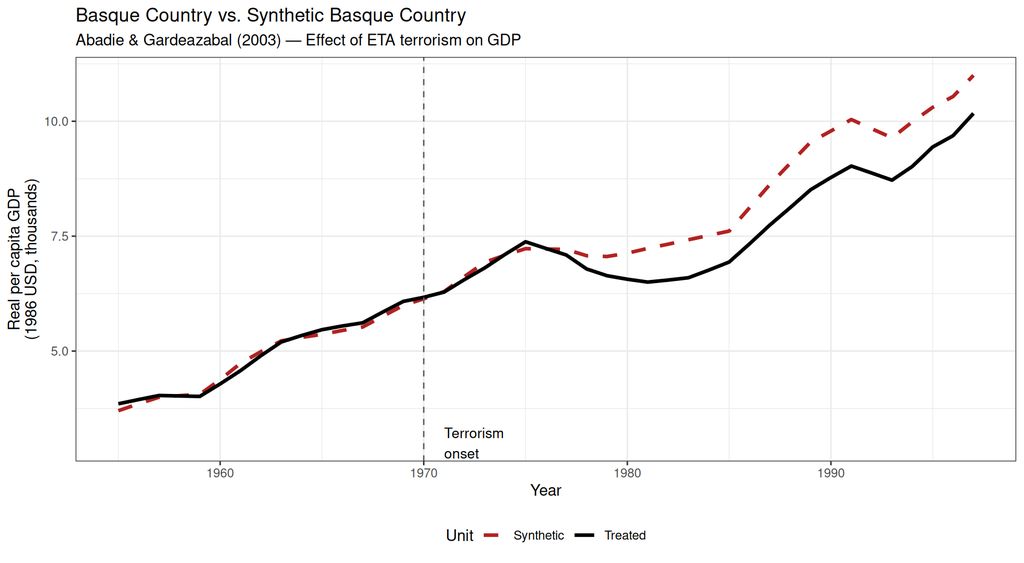

## Basque Country: Treatment Effect (Gap Plot)

```r
gap <- as.numeric(Y_treat) - as.numeric(Y_synth)
gap_df <- data.frame(year = years, gap = gap)

ggplot(gap_df, aes(x = year, y = gap)) +
  geom_line(linewidth = 1.2) +
  geom_hline(yintercept = 0, linetype = "dashed") +
  geom_vline(xintercept = 1970, linetype = "dashed", color = "gray40") +
  annotate("text", x = 1971, y = 0.4, label = "Terrorism onset", hjust = 0, size = 3.5) +
  labs(x = "Year", y = "Gap in real per capita GDP\n(Treated − Synthetic)",
       title = "Estimated effect of terrorism on Basque Country GDP",
       subtitle = "Negative gap = terrorism reduced GDP relative to synthetic control") +
  theme_bw()
```

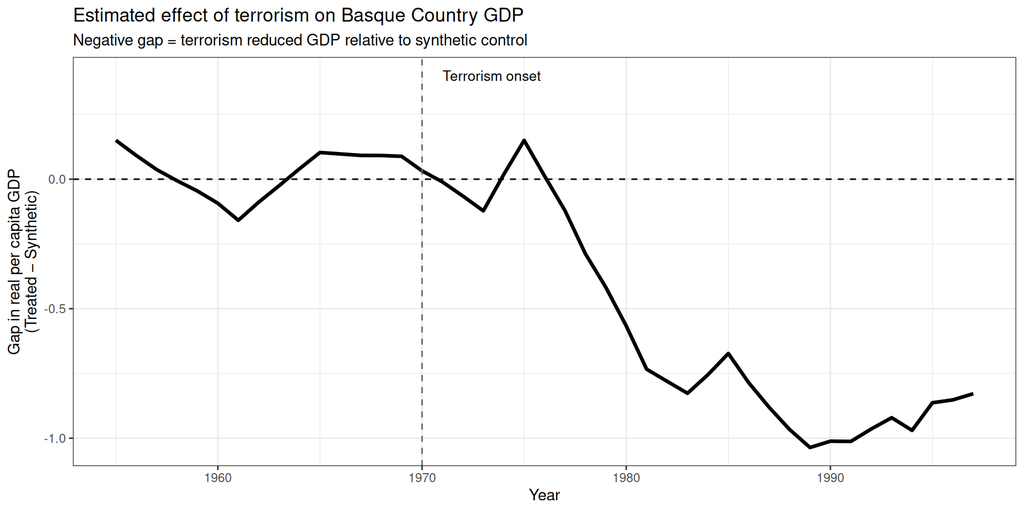

## SCM: Inference

- With a single treated unit, standard inference is not straightforward. **Abadie et al. (2010)** propose a **permutation testing** approach:
  - Apply SCM to **each donor unit** as if it were treated
  - If the treated unit’s gap is unusually large relative to these “placebo” gaps, the effect is unlikely due to chance
  - **Test statistic**: post/pre RMSPE ratio
  - Common practice to drop controls with egregiously worse pre-treatment fit compared to treated unit.
- Recent work in statistics moves beyond this:
  - “Conformal inference” approach in **Chernozhukov, Wüthrich, and Zhu (2019)**

## Basque Country: Permutation tests

```r
# Run placebo tests for each control region
control_ids <- c(2:16, 18)
placebo_gaps <- list()

for (ctrl_id in control_ids) {
  donor_ids <- setdiff(c(2:16, 18), ctrl_id)

  tryCatch({
    dp <- dataprep(
      foo = basque,
      predictors = c("school.illit", "school.prim", "school.med",
                     "school.high", "school.post.high", "invest"),
      predictors.op = "mean",
      time.predictors.prior = 1964:1969,
      special.predictors = list(
        list("gdpcap", 1960:1969, "mean"),
        list("sec.agriculture", seq(1961, 1969, 2), "mean"),
        list("sec.energy", seq(1961, 1969, 2), "mean"),
        list("sec.industry", seq(1961, 1969, 2), "mean"),
        list("sec.construction", seq(1961, 1969, 2), "mean"),
        list("sec.services.venta", seq(1961, 1969, 2), "mean"),
        list("sec.services.nonventa", seq(1961, 1969, 2), "mean"),
        list("popdens", 1969, "mean")
      ),
      dependent = "gdpcap",
      unit.variable = "regionno",
      unit.names.variable = "regionname",
      time.variable = "year",
      treatment.identifier = ctrl_id,
      controls.identifier = donor_ids,
      time.optimize.ssr = 1960:1969,
      time.plot = 1955:1997
    )

    so <- synth(data.prep.obj = dp, method = "BFGS")

    y1 <- as.numeric(dp$Y1plot)
    y0 <- as.numeric(dp$Y0plot %*% so$solution.w)
    placebo_gaps[[as.character(ctrl_id)]] <- data.frame(
      year = 1955:1997, gap = y1 - y0, unit = ctrl_id
    )
  }, error = function(e) {
    # Skip units where optimization fails
  })
}

placebo_df <- do.call(rbind, placebo_gaps)

# Add treated unit
treated_gap_df <- data.frame(year = years, gap = gap, unit = 17)
```

## Basque Country: Permutation tests

```r
ggplot() +
  geom_line(data = placebo_df, aes(x = year, y = gap, group = unit),
            color = "gray70", alpha = 0.6) +
  geom_line(data = treated_gap_df, aes(x = year, y = gap),
            color = "black", linewidth = 1.2) +
  geom_vline(xintercept = 1970, linetype = "dashed", color = "gray40") +
  geom_hline(yintercept = 0, linetype = "dashed") +
  labs(x = "Year", y = "Gap in real per capita GDP",
       title = "Placebo tests: Basque Country (black) vs. donor regions (gray)",
       subtitle = "Each gray line = SCM applied to a donor region as if it were treated") +
  theme_bw()
```

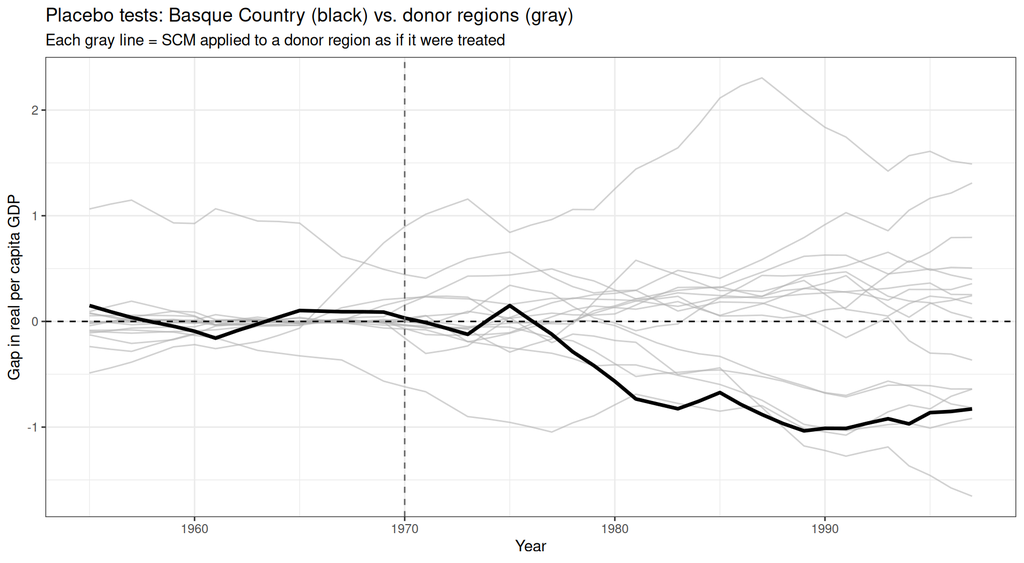

## Permutation Tests: Dropping Poor Fits

```r
# Compute pre-treatment RMSPE for each unit
treated_pre_rmspe <- sqrt(mean((treated_gap_df %>% filter(year < 1970))$gap^2))

placebo_pre_rmspe <- placebo_df %>%
  filter(year < 1970) %>%
  group_by(unit) %>%
  summarize(pre_rmspe = sqrt(mean(gap^2))) %>%
  ungroup()

# Keep only units with pre-RMSPE <= 5x the treated unit
keep_units <- placebo_pre_rmspe %>%
  filter(pre_rmspe <= 5 * treated_pre_rmspe) %>%
  pull(unit)

placebo_df_trimmed <- placebo_df %>% filter(unit %in% keep_units)

n_dropped <- n_distinct(placebo_df$unit) - length(keep_units)

ggplot() +
  geom_line(data = placebo_df_trimmed, aes(x = year, y = gap, group = unit),
            color = "gray70", alpha = 0.6) +
  geom_line(data = treated_gap_df, aes(x = year, y = gap),
            color = "black", linewidth = 1.2) +
  geom_vline(xintercept = 1970, linetype = "dashed", color = "gray40") +
  geom_hline(yintercept = 0, linetype = "dashed") +
  labs(x = "Year", y = "Gap in real per capita GDP",
       title = paste0("Placebo tests: Dropping donors with pre-RMSPE > 5x treated (",
                      n_dropped, " dropped)"),
       subtitle = "Basque Country (black) vs. donor regions with adequate pre-treatment fit (gray)") +
  theme_bw()
```

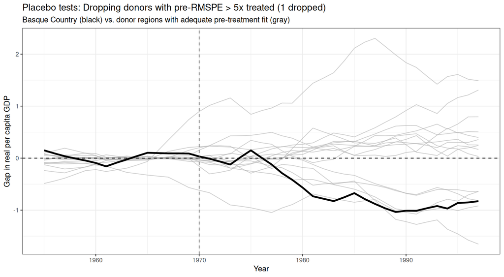

## Permutation Tests: RMSPE Ratios

```r
# Compute post/pre RMSPE ratios
compute_rmspe_ratio <- function(gap_df, treatment_year = 1970) {
  pre <- gap_df %>% filter(year < treatment_year)
  post <- gap_df %>% filter(year >= treatment_year)
  rmspe_pre <- sqrt(mean(pre$gap^2))
  rmspe_post <- sqrt(mean(post$gap^2))
  rmspe_post / rmspe_pre
}

# Treated unit ratio
treated_ratio <- compute_rmspe_ratio(treated_gap_df)

# Placebo ratios
placebo_ratios <- placebo_df %>%
  group_by(unit) %>%
  group_modify(~ tibble(ratio = compute_rmspe_ratio(.x))) %>%
  ungroup()

all_ratios <- bind_rows(
  placebo_ratios,
  tibble(unit = 17, ratio = treated_ratio)
) %>%
  mutate(is_treated = unit == 17)

# Compute p-value
pval <- mean(all_ratios$ratio >= treated_ratio)

ggplot(all_ratios, aes(x = ratio, fill = is_treated)) +
  geom_histogram(bins = 15, color = "white", alpha = 0.8) +
  geom_vline(xintercept = treated_ratio, linetype = "dashed", color = "red", linewidth = 1) +
  scale_fill_manual(values = c("FALSE" = "gray70", "TRUE" = "black"),
                    labels = c("Donor regions", "Basque Country"),
                    name = "") +
  labs(x = "Post/Pre RMSPE Ratio",
       y = "Count",
       title = "Distribution of RMSPE ratios: Permutation inference",
       subtitle = paste0("Basque Country ratio = ", round(treated_ratio, 2),
                         " | p-value = ", round(pval, 3))) +
  theme_bw() + theme(legend.position = "bottom")
```

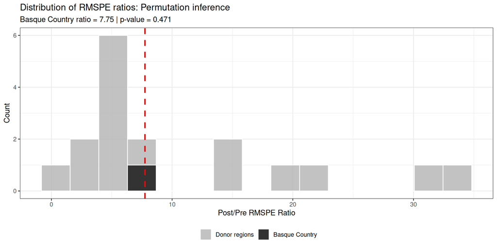

## Staggered Adoption SCM

- Conventional SCM is designed for **one** treated unit — what if multiple units are treated?
  - What should we weight our control pool to - each unit **separately** or the **average** of the units?
- We might get perfect balance for the **average** of the units but terrible fit for individual treated units!
- **Ben-Michael, Feller and Rothstein (2022)** show that the bias is a **combination** of these two imbalances.
  - Propose a **partial pooling** approach that minimizes a combination of the two.
- Implemented in the `augsynth` R package (along with their outcome-augmented synthetic control)

## multisynth: Average Effect Across Treated Units

```r
library(augsynth)

# Use multisynth for the multi-unit case
# multisynth infers treatment timing from the binary indicator
msyn <- multisynth(
  RepVotesMajorPercent ~ treated,
  unit = county_state, time = year,
  data = dff
)

msyn_summ <- summary(msyn)

# Extract average ATT for plotting
avg_att <- msyn_summ$att %>%
  filter(Level == "Average")

ggplot(avg_att, aes(x = Time, y = Estimate)) +
  geom_point(size = 3) +
  geom_errorbar(aes(ymin = lower_bound, ymax = upper_bound), width = 0.3) +
  geom_hline(yintercept = 0, linetype = "dashed") +
  geom_vline(xintercept = -0.5, linetype = "dashed", color = "red") +
  labs(x = "Time relative to treatment (election cycles)",
       y = "Estimated ATT (pp)",
       title = "Multisynth: Effect of shale shock on Republican vote share",
       subtitle = "Average across treated coal counties (partially pooled SCM)") +
  theme_bw()
```

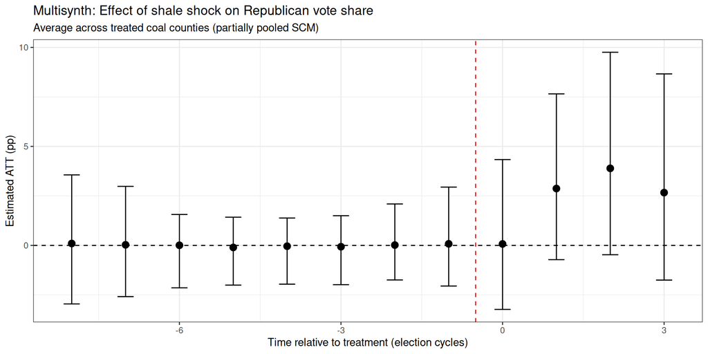

## Placebo testing

- We’ve **fit** the synthetic control model to minimize pre-treatment outcome discrepancies.
  - A perfect synthetic control will reproduce the trajectory **exactly**
  - But this doesn’t mean that our estimator is unbiased - especially if we have a short panel.
  - How do we assess whether the bias is small?
    - **Perfect pre-treatment fit** is no longer a valid **placebo test**!
- We can use a **placebo test** approach where we **backdate** the treatment to an earlier period and check whether the synthetic control produces spurious “effects” in held-out pre-treatment periods
  - Same intuition as our discussion last week - we want our placebo tests to involve **held-out** comparisons.

## Backdating falsification tests

```r
# In-time falsification: backdate treatment to 2000 and 1996
# Fit SCM using only pre-placebo data, check for "effects" in held-out periods

placebo_years <- c(1996, 2000, 2004)

falsification_results <- list()

for (placebo_yr in placebo_years) {
  # Create dataset: only pre-2008 data, with treatment backdated
  falsification_df <- dff %>%
    filter(year < 2008) %>%
    mutate(placebo_treat = as.integer(treat == 1 & year >= placebo_yr))

  tryCatch({
    plac_fit <- multisynth(
      RepVotesMajorPercent ~ placebo_treat,
      unit = county_state, time = year,
      data = falsification_df,
    )

    plac_summ <- summary(plac_fit)
    plac_att <- plac_summ$att %>%
      filter(Level == "Average") %>%
      mutate(placebo_year = placebo_yr)

    falsification_results[[as.character(placebo_yr)]] <- plac_att
  }, error = function(e) {
    cat("Error for placebo year", placebo_yr, ":", conditionMessage(e), "\n")
  })
}

all_results <- bind_rows(
  do.call(rbind, falsification_results)
) %>%
  mutate(placebo_label = paste0("Placebo treatment = ", placebo_year))

ggplot(all_results, aes(x = Time, y = Estimate,
                         color = factor(placebo_year))) +
  geom_point(size = 2.5) +
  geom_errorbar(aes(ymin = lower_bound, ymax = upper_bound), width = 0.3) +
  geom_hline(yintercept = 0, linetype = "dashed") +
  geom_vline(xintercept = -0.5, linetype = "dotted") +
  facet_wrap(~ placebo_label, scales = "free_x") +
  labs(x = "Time relative to (placebo) treatment",
       y = "Estimated ATT (pp)",
       title = "Placebo tests: backdated treatment vs. actual",
       subtitle = "Placebo treatments should show no effect in held-out pre-2008 periods") +
  scale_color_manual(values = c("1996" = "steelblue", "2000" = "darkorange",
                                 "2004" = "black")) +
  theme_bw() + theme(legend.position = "none")
```

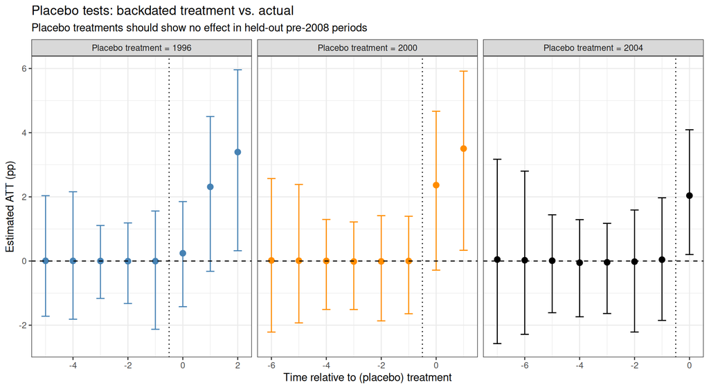

## Conclusion

- Causal inference in time-series data is **hard**!
  - Even the estimands can get tricky - we’ll come back to this again when we talk about **mediation**
- The core problem centers around how we deal with **unobserved confounding** and the role that **past outcomes** play in identification/estimation
- Three scenarios:
  - Unobserved confounding but simple functional form (DiD)
    - Adjust via **differencing** - works in short panels
  - Observed confounding driven by past $Y$
    - Adjust by **controlling** for past $Y$ - also fine in short panels
  - Unobserved confounding more complex than DiD
    - Adjust for past $Y$ to indirectly control for the latent factor - need **many** pre-treatment periods!

## Next week

- The last of the “holy trinity” - **regression discontinuity designs**
- What happens when we have arbitrary unobserved confounding…
  - …but treatment is assigned via a **threshold**
- In this case, even if treatment-outcome are confounded, that confounding might be **negligible** in the window around the threshold!
- Two ways to think about this
  - “As-if-random” assignment at the cut-off
  - Continuity in potential outcomes at the cut-off
- Estimation by **extrapolation** to the threshold.
  - Works best when we have **lots of units** near the cut-off.